# Raport - Repartitii discrete si continue

### 11.Fisher

Density function: Df1 = 1, Df2 = 1, Ncp = 1, a = 2, b = 5

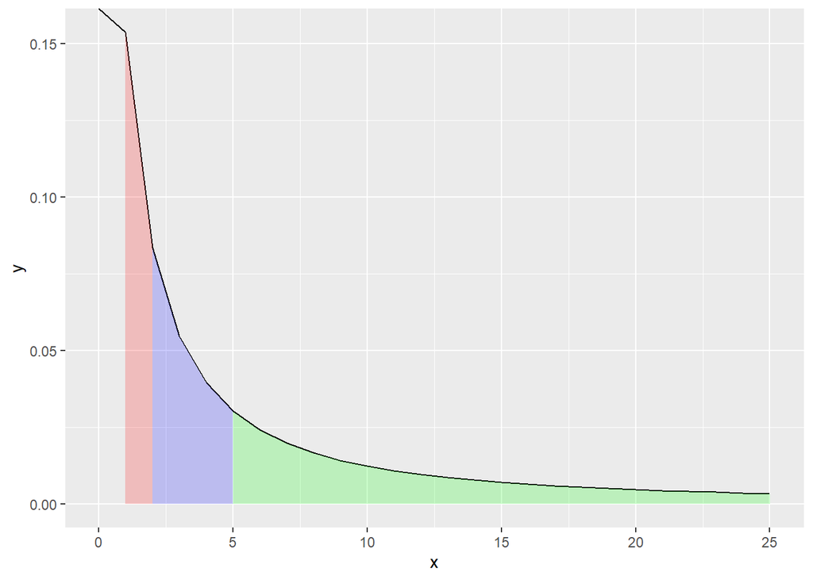

```r
library(ggplot2)
df1 <- 1
      df2 <- 1
      ncp <- 1
      x <- 0:25
      y <- df(x, df1 = df1,df2 = df2, ncp = ncp)
      ggplot(data.frame(x, y), aes(x, y)) +
        geom_line() +
        geom_area(data = data.frame(x = x[x<=2], y = y[x<=2]), aes(x, y), fill = "red", alpha = 0.2) +
        geom_area(data = data.frame(x = x[x>=5], y = y[x>=5]), aes(x, y), fill = "green", alpha = 0.2) +
        geom_area(data = data.frame(x = x[x>=2 & x<=5], y = y[x>=2 & x<=5]), aes(x, y), fill = "blue", alpha = 0.2)
```

Mass function: Df1 = 1, Df2 = 1, Ncp = 1, a = 2, b = 5

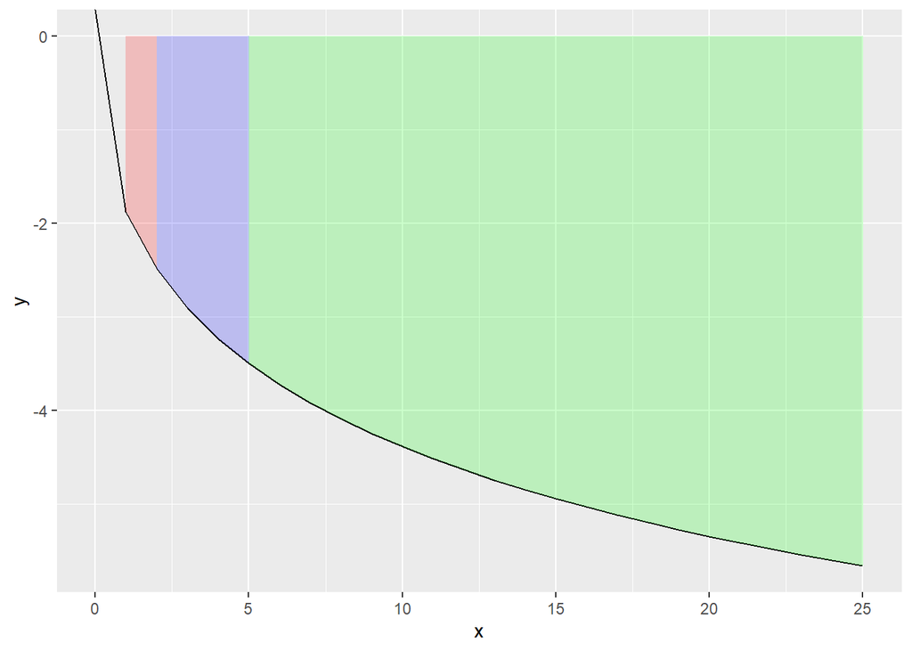

```r
library(ggplot2)
df1 <- 1
      df2 <- 1
      ncp <- 1
      x <- 0:25
      y <- df(x, df1 = df1,df2 = df2, ncp = ncp, log = TRUE)
      ggplot(data.frame(x, y), aes(x, y)) +
        geom_line() +
        geom_area(data = data.frame(x = x[x<=2], y = y[x<=2]), aes(x, y), fill = "red", alpha = 0.2) +
        geom_area(data = data.frame(x = x[x>=5], y = y[x>=5]), aes(x, y), fill = "green", alpha = 0.2) +
        geom_area(data = data.frame(x = x[x>=2 & x<=5], y = y[x>=2 & x<=5]), aes(x, y), fill = "blue", alpha = 0.2)
```

Repartition function: Df1 = 1, Df2 = 1, Ncp = 1, a = 2, b = 5

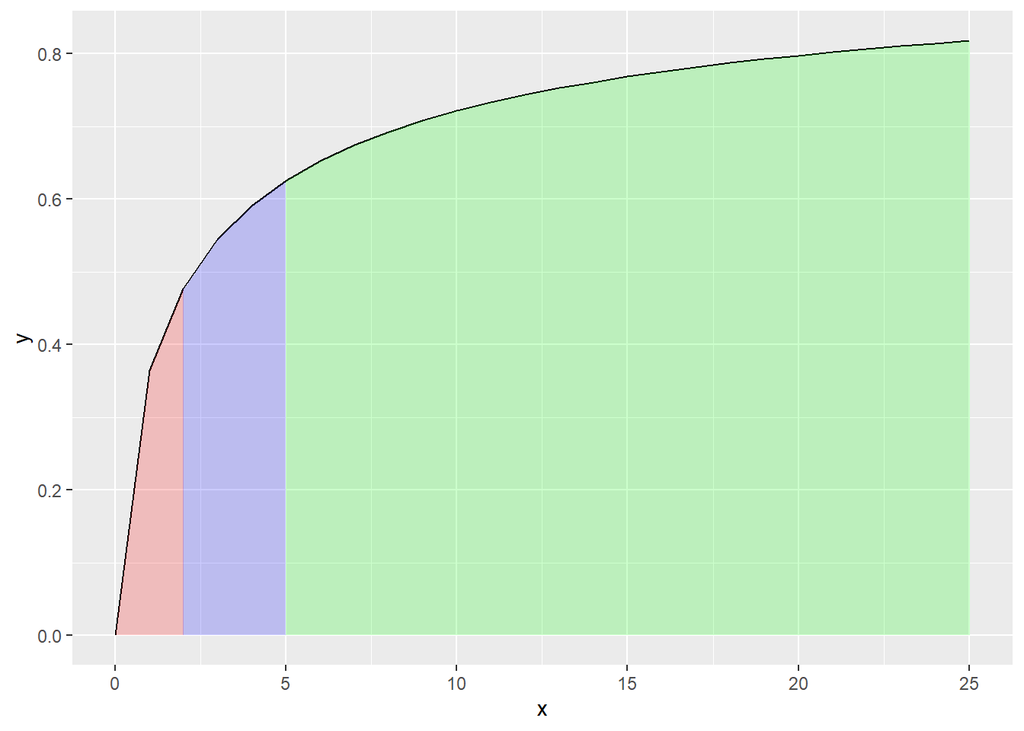

```r
library(ggplot2)
df1 <- 1
      df2 <- 1
      ncp <- 1
      x <- 0:25
      y <- pf(x, df1 = df1,df2 = df2, ncp = ncp)
      ggplot(data.frame(x, y), aes(x, y)) +
        geom_line() +
        geom_area(data = data.frame(x = x[x<=2], y = y[x<=2]), aes(x, y), fill = "red", alpha = 0.2) +
        geom_area(data = data.frame(x = x[x>=5], y = y[x>=5]), aes(x, y), fill = "green", alpha = 0.2) +
        geom_area(data = data.frame(x = x[x>=2 & x<=5], y = y[x>=2 & x<=5]), aes(x, y), fill = "blue", alpha = 0.2)
```

### 12.Cauchy

Density function: Location = 1, Scale = 1, a = 2, b = 4

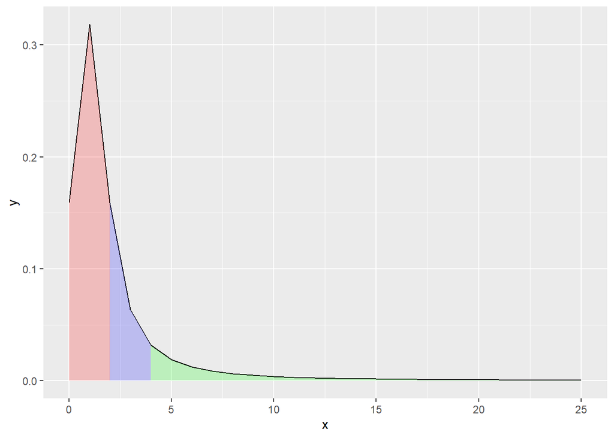

```r
library(ggplot2)

l <- 1
      s <- 1
      x <- 0:25
      y <- dcauchy(x, location = l, scale = s)
      ggplot(data.frame(x, y), aes(x, y)) +
        geom_line() +
        geom_area(data = data.frame(x = x[x<=2], y = y[x<=2]), aes(x, y), fill = "red", alpha = 0.2) +
        geom_area(data = data.frame(x = x[x>=4], y = y[x>=4]), aes(x, y), fill = "green", alpha = 0.2) +
        geom_area(data = data.frame(x = x[x>=2 & x<=4], y = y[x>=2 & x<=4]), aes(x, y), fill = "blue", alpha = 0.2)
```

Mass function: Location = 1, Scale = 1, a = 2, b = 4

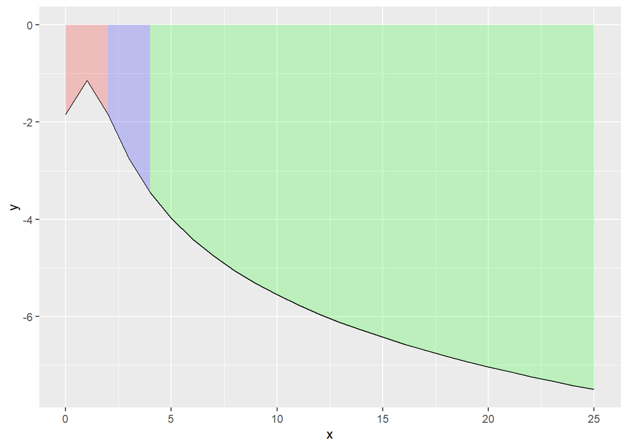

```r
library(ggplot2)

l <- 1
      s <- 1
      x <- 0:25
      y <- dcauchy(x, location = l, scale = s, log = TRUE)
      ggplot(data.frame(x, y), aes(x, y)) +
        geom_line() +
        geom_area(data = data.frame(x = x[x<=2], y = y[x<=2]), aes(x, y), fill = "red", alpha = 0.2) +
        geom_area(data = data.frame(x = x[x>=4], y = y[x>=4]), aes(x, y), fill = "green", alpha = 0.2) +
        geom_area(data = data.frame(x = x[x>=2 & x<=4], y = y[x>=2 & x<=4]), aes(x, y), fill = "blue", alpha = 0.2)
```

Repartition function: Location = 1, Scale = 1, a = 2, b = 4

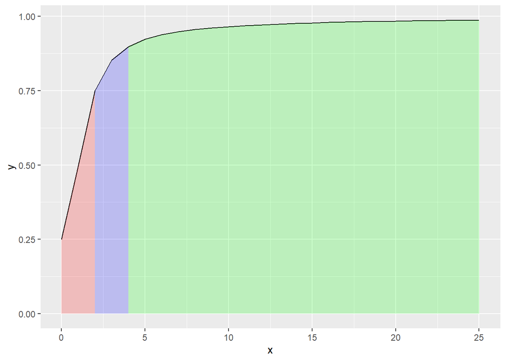

```r
library(ggplot2)

l <- 1
      s <- 1
      x <- 0:25
      y <- pcauchy(x, location = l, scale = s)
      ggplot(data.frame(x, y), aes(x, y)) +
        geom_line() +
        geom_area(data = data.frame(x = x[x<=2], y = y[x<=2]), aes(x, y), fill = "red", alpha = 0.2) +
        geom_area(data = data.frame(x = x[x>=4], y = y[x>=4]), aes(x, y), fill = "green", alpha = 0.2) +
        geom_area(data = data.frame(x = x[x>=2 & x<=4], y = y[x>=2 & x<=4]), aes(x, y), fill = "blue", alpha = 0.2)
```

### 13.Chy-Squared

Density function: Df = 1, Ncp = 1, a = 2, b = 4

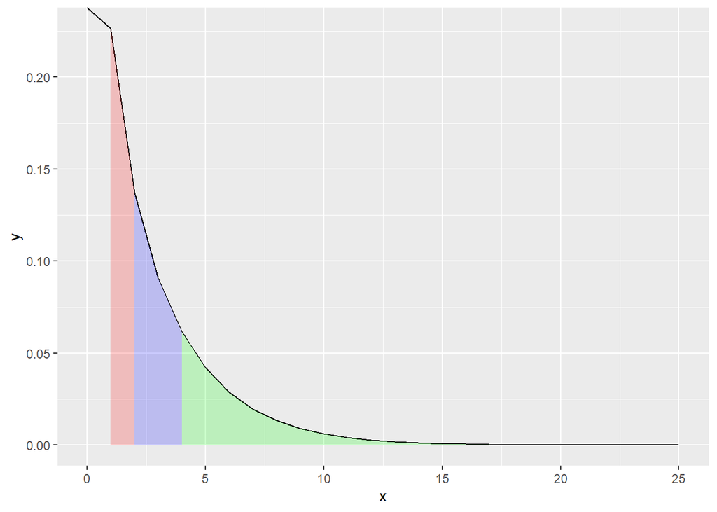

```r
library(ggplot2)
df <- 1
      ncp <- 1
      x <- 0:25
      y <- dchisq(x, df = df, ncp = ncp)
      ggplot(data.frame(x, y), aes(x, y)) +
        geom_line() +
        geom_area(data = data.frame(x = x[x<=2], y = y[x<=2]), aes(x, y), fill = "red", alpha = 0.2) +
        geom_area(data = data.frame(x = x[x>=4], y = y[x>=4]), aes(x, y), fill = "green", alpha = 0.2) +
        geom_area(data = data.frame(x = x[x>=2 & x<=4], y = y[x>=2 & x<=4]), aes(x, y), fill = "blue", alpha = 0.2)
```

Mass function: Df = 1, Ncp = 1, a = 2, b = 4

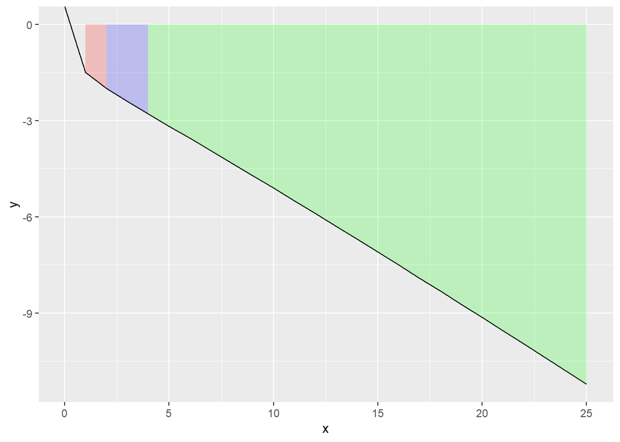

```r
library(ggplot2)
df <- 1
      ncp <- 1
      x <- 0:25
      y <- dchisq(x, df = df, ncp = ncp, log = TRUE)
      ggplot(data.frame(x, y), aes(x, y)) +
        geom_line() +
        geom_area(data = data.frame(x = x[x<=2], y = y[x<=2]), aes(x, y), fill = "red", alpha = 0.2) +
        geom_area(data = data.frame(x = x[x>=4], y = y[x>=4]), aes(x, y), fill = "green", alpha = 0.2) +
        geom_area(data = data.frame(x = x[x>=2 & x<=4], y = y[x>=2 & x<=4]), aes(x, y), fill = "blue", alpha = 0.2)
```

Repartition function: Df = 1, Ncp = 1, a = 2, b = 4

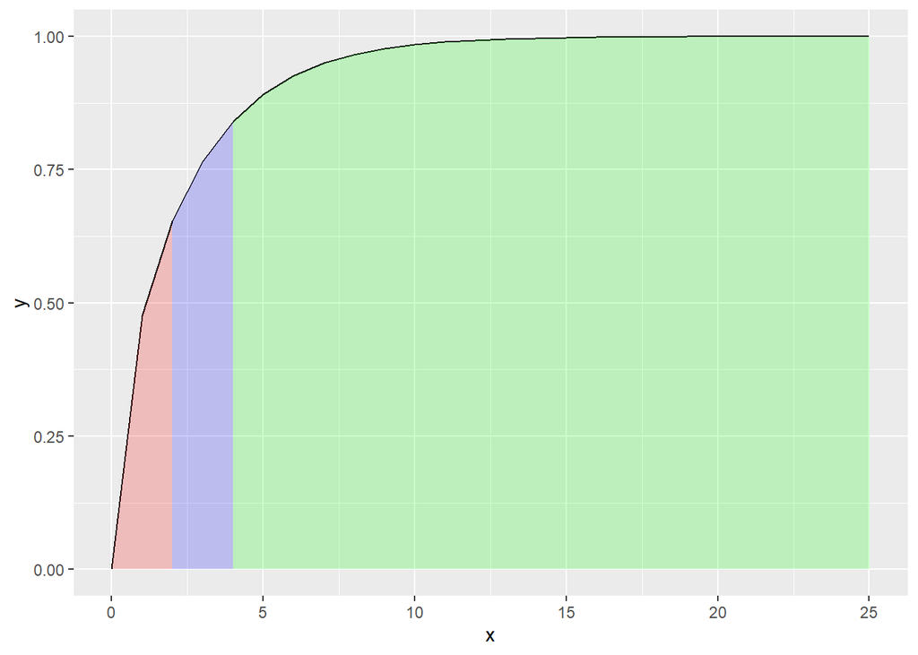

```r
library(ggplot2)
df <- 1
      ncp <- 1
      x <- 0:25
      y <- pchisq(x, df = df, ncp = ncp)
      ggplot(data.frame(x, y), aes(x, y)) +
        geom_line() +
        geom_area(data = data.frame(x = x[x<=2], y = y[x<=2]), aes(x, y), fill = "red", alpha = 0.2) +
        geom_area(data = data.frame(x = x[x>=4], y = y[x>=4]), aes(x, y), fill = "green", alpha = 0.2) +
        geom_area(data = data.frame(x = x[x>=2 & x<=4], y = y[x>=2 & x<=4]), aes(x, y), fill = "blue", alpha = 0.2)
```

### 14.Laplace

Density function: Mu = 1, Sigma = 1, a = 1, b = 3

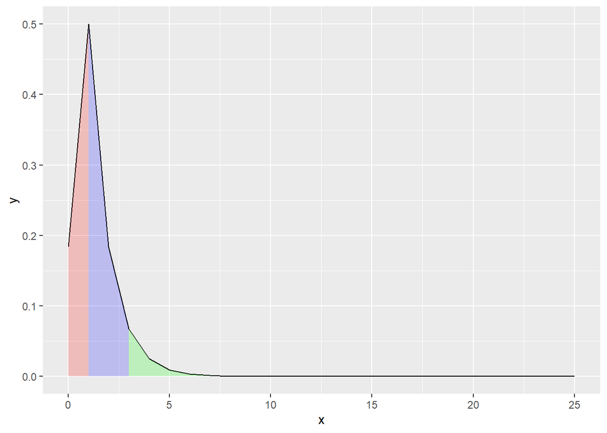

```r
library(ggplot2)
library(extraDistr)
m <- 1
      s <- 1
      x <- 0:25
      y <- dlaplace(x, mu = m, sigma = s)
      ggplot(data.frame(x, y), aes(x, y)) +
        geom_line() +
        geom_area(data = data.frame(x = x[x<=1], y = y[x<=1]), aes(x, y), fill = "red", alpha = 0.2) +
        geom_area(data = data.frame(x = x[x>=3], y = y[x>=3]), aes(x, y), fill = "green", alpha = 0.2) +
        geom_area(data = data.frame(x = x[x>=1 & x<=3], y = y[x>=1 & x<=3]), aes(x, y), fill = "blue", alpha = 0.2)
```

Mass function: Mu = 1, Sigma = 1, a = 1, b = 3

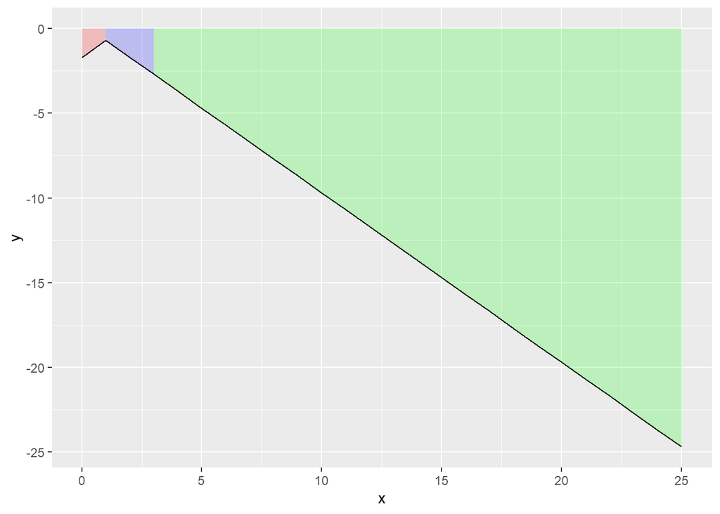

```r
library(ggplot2)
library(extraDistr)
m <- 1
      s <- 1
      x <- 0:25
      y <- dlaplace(x, mu = m, sigma = s, log = TRUE)
      ggplot(data.frame(x, y), aes(x, y)) +
        geom_line() +
        geom_area(data = data.frame(x = x[x<=1], y = y[x<=1]), aes(x, y), fill = "red", alpha = 0.2) +
        geom_area(data = data.frame(x = x[x>=3], y = y[x>=3]), aes(x, y), fill = "green", alpha = 0.2) +
        geom_area(data = data.frame(x = x[x>=1 & x<=3], y = y[x>=1 & x<=3]), aes(x, y), fill = "blue", alpha = 0.2)
```

Repartition function: Mu = 1, Sigma = 1, a = 1, b = 3

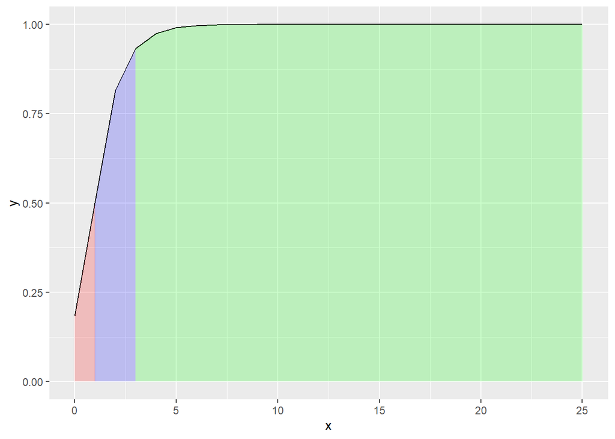

```r
library(ggplot2)
library(extraDistr)
m <- 1
      s <- 1
      x <- 0:25
      y <- plaplace(x, mu = m, sigma = s)
      ggplot(data.frame(x, y), aes(x, y)) +
        geom_line() +
        geom_area(data = data.frame(x = x[x<=1], y = y[x<=1]), aes(x, y), fill = "red", alpha = 0.2) +
        geom_area(data = data.frame(x = x[x>=3], y = y[x>=3]), aes(x, y), fill = "green", alpha = 0.2) +
        geom_area(data = data.frame(x = x[x>=1 & x<=3], y = y[x>=1 & x<=3]), aes(x, y), fill = "blue", alpha = 0.2)
```

### 15.Pareto

Density function: A = 1, B = 1, a = 1, b = 3

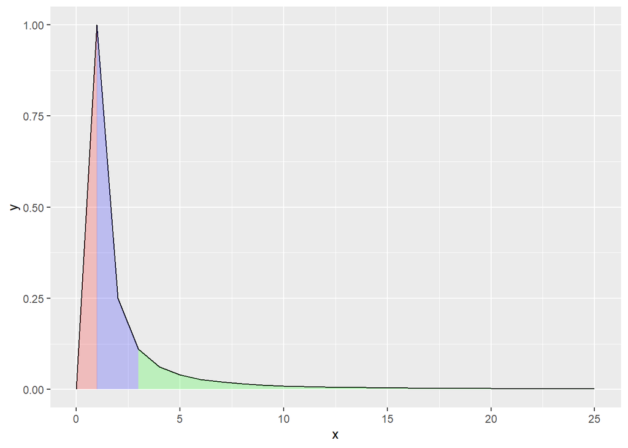

```r
library(ggplot2)
library(extraDistr)
aP <- 1
      bP <- 1
      x <- 0:25
      y <- dpareto(x, a = aP, b = bP)
      ggplot(data.frame(x, y), aes(x, y)) +
        geom_line() +
        geom_area(data = data.frame(x = x[x<=1], y = y[x<=1]), aes(x, y), fill = "red", alpha = 0.2) +
        geom_area(data = data.frame(x = x[x>=3], y = y[x>=3]), aes(x, y), fill = "green", alpha = 0.2) +
        geom_area(data = data.frame(x = x[x>=1 & x<=3], y = y[x>=1 & x<=3]), aes(x, y), fill = "blue", alpha = 0.2)
```

Mass function: A = 1, B = 1, a = 1, b = 3

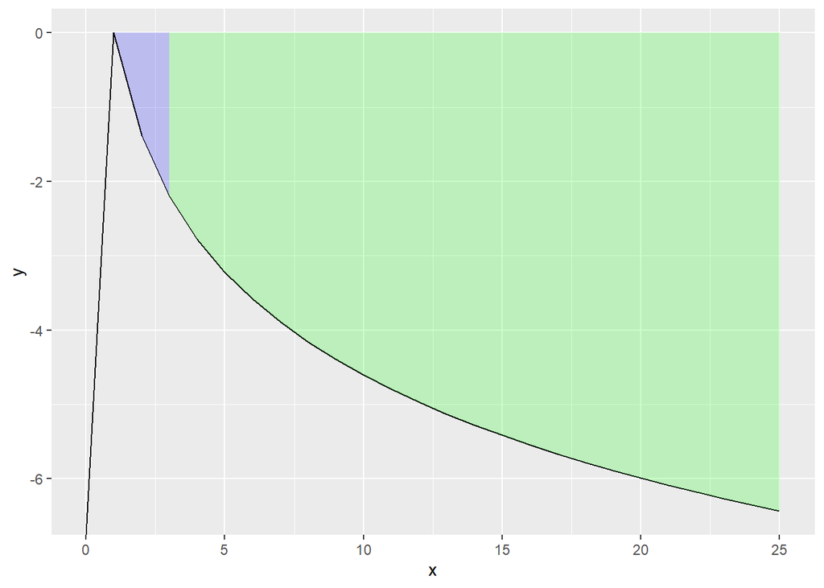

```r
library(ggplot2)
library(extraDistr)
aP <- 1
      bP <- 1
      x <- 0:25
      y <- dpareto(x, a = aP, b = bP, log = TRUE)
      ggplot(data.frame(x, y), aes(x, y)) +
        geom_line() +
        geom_area(data = data.frame(x = x[x<=1], y = y[x<=1]), aes(x, y), fill = "red", alpha = 0.2) +
        geom_area(data = data.frame(x = x[x>=3], y = y[x>=3]), aes(x, y), fill = "green", alpha = 0.2) +
        geom_area(data = data.frame(x = x[x>=1 & x<=3], y = y[x>=1 & x<=3]), aes(x, y), fill = "blue", alpha = 0.2)
```

Repartition function: A = 1, B = 1, a = 1, b = 3

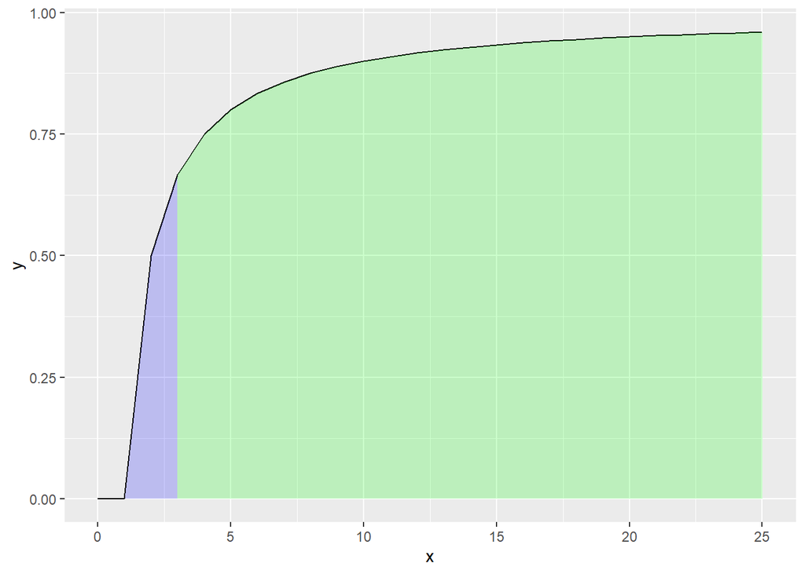

```r
library(ggplot2)
library(extraDistr)
aP <- 1
      bP <- 1
      x <- 0:25
      y <- ppareto(x, a = aP, b = bP)
      ggplot(data.frame(x, y), aes(x, y)) +
        geom_line() +
        geom_area(data = data.frame(x = x[x<=1], y = y[x<=1]), aes(x, y), fill = "red", alpha = 0.2) +
        geom_area(data = data.frame(x = x[x>=3], y = y[x>=3]), aes(x, y), fill = "green", alpha = 0.2) +
        geom_area(data = data.frame(x = x[x>=1 & x<=3], y = y[x>=1 & x<=3]), aes(x, y), fill = "blue", alpha = 0.2)
```